# Classification_Trees

```python
!jt -r
```

```
Reset css and font defaults in:
/home/goncalo/.jupyter/custom &
/home/goncalo/.local/share/jupyter/nbextensions
```

```python
!jt -t chesterish
```

```
Didn't recognize theme name: default
Available Themes:
   chesterish
   grade3
   gruvboxd
   gruvboxl
   monokai
   oceans16
   onedork
   solarizedd
   solarizedl
```

# Classification Trees in Python

- Uses scikit-learn and Cost Complexity Pruning
- Uses continuous and categorical data from the UCI Machine Learning Repository to **predict whether or not a patient has heart disease**.

#### Import the modules

```python
import pandas as pd
import numpy as np
import matplotlib.pyplot as plt

from sklearn.tree import DecisionTreeClassifier # build classification trees
from sklearn.tree import plot_tree # draw classification trees
from sklearn.model_selection import train_test_split # split data into training and testing sets
from sklearn.model_selection import cross_val_score # for cross validation
from sklearn.metrics import confusion_matrix # create confusion matrix
from sklearn.metrics import plot_confusion_matrix # plot confusion matrix
%pwd
```

```
'/home/goncalo/Desktop/ML'
```

```python
# dataset from https://archive.ics.uci.edu/ml/datasets/Heart+Disease
#df = pd.read_csv('processed.cleveland.data', header=None)

df = pd.read_csv('https://archive.ics.uci.edu/ml/machine-learning-databases/heart-disease/processed.cleveland.data',
                header=None)

print('The columns in the data file:')
print(df.columns)
print('The sample contains ' + str(len(df)) + ' sources')
df.head()
```

```
The columns in the data file:
Int64Index([0, 1, 2, 3, 4, 5, 6, 7, 8, 9, 10, 11, 12, 13], dtype='int64')
The sample contains 303 sources
```

|  | 0 | 1 | 2 | 3 | 4 | 5 | 6 | 7 | 8 | 9 | 10 | 11 | 12 | 13 |
| --- | --- | --- | --- | --- | --- | --- | --- | --- | --- | --- | --- | --- | --- | --- |
| 0 | 63.0 | 1.0 | 1.0 | 145.0 | 233.0 | 1.0 | 2.0 | 150.0 | 0.0 | 2.3 | 3.0 | 0.0 | 6.0 | 0 |
| 1 | 67.0 | 1.0 | 4.0 | 160.0 | 286.0 | 0.0 | 2.0 | 108.0 | 1.0 | 1.5 | 2.0 | 3.0 | 3.0 | 2 |
| 2 | 67.0 | 1.0 | 4.0 | 120.0 | 229.0 | 0.0 | 2.0 | 129.0 | 1.0 | 2.6 | 2.0 | 2.0 | 7.0 | 1 |
| 3 | 37.0 | 1.0 | 3.0 | 130.0 | 250.0 | 0.0 | 0.0 | 187.0 | 0.0 | 3.5 | 3.0 | 0.0 | 3.0 | 0 |
| 4 | 41.0 | 0.0 | 2.0 | 130.0 | 204.0 | 0.0 | 2.0 | 172.0 | 0.0 | 1.4 | 1.0 | 0.0 | 3.0 | 0 |

Attribute Information from the archive:

Only 14 attributes used:

# 3 (age)

# 4 (sex)

# 9 (cp)

# 10 (trestbps)

# 12 (chol)

# 16 (fbs)

# 19 (restecg)

# 32 (thalach)

# 38 (exang)

# 40 (oldpeak)

# 41 (slope)

# 44 (ca)

# 51 (thal)

# 58 (num) (the predicted attribute)

```python
df.columns = ['age','sex','cp','restbp','chol','fbs','restecg',
              'thalach','exang','oldpeak','slope','ca','thal','hd']
df.head()
```

|  | age | sex | cp | restbp | chol | fbs | restecg | thalach | exang | oldpeak | slope | ca | thal | hd |
| --- | --- | --- | --- | --- | --- | --- | --- | --- | --- | --- | --- | --- | --- | --- |
| 0 | 63.0 | 1.0 | 1.0 | 145.0 | 233.0 | 1.0 | 2.0 | 150.0 | 0.0 | 2.3 | 3.0 | 0.0 | 6.0 | 0 |
| 1 | 67.0 | 1.0 | 4.0 | 160.0 | 286.0 | 0.0 | 2.0 | 108.0 | 1.0 | 1.5 | 2.0 | 3.0 | 3.0 | 2 |
| 2 | 67.0 | 1.0 | 4.0 | 120.0 | 229.0 | 0.0 | 2.0 | 129.0 | 1.0 | 2.6 | 2.0 | 2.0 | 7.0 | 1 |
| 3 | 37.0 | 1.0 | 3.0 | 130.0 | 250.0 | 0.0 | 0.0 | 187.0 | 0.0 | 3.5 | 3.0 | 0.0 | 3.0 | 0 |
| 4 | 41.0 | 0.0 | 2.0 | 130.0 | 204.0 | 0.0 | 2.0 | 172.0 | 0.0 | 1.4 | 1.0 | 0.0 | 3.0 | 0 |

# Missing Data: scikit-learn's classification trees do not support datasets with missing values

## Part 1: Identifying Missing Data

1. See what sort of data is in each column

```python
df.dtypes
```

```
age        float64
sex        float64
cp         float64
restbp     float64
chol       float64
fbs        float64
restecg    float64
thalach    float64
exang      float64
oldpeak    float64
slope      float64
ca          object
thal        object
hd           int64
dtype: object
```

**df['ca'] and df['thal'] should be float/int, not object type** -> probably mixture of types

2. Investigate the set of unique values for these columns

```python
df['ca'].unique()
```

```
array(['0.0', '3.0', '2.0', '1.0', '?'], dtype=object)
```

```python
df['thal'].unique()
```

```
array(['6.0', '3.0', '7.0', '?'], dtype=object)
```

**Question marks '?' represent missing data** -> needs to be dealt with

## Part 2: Dealing with Missing Data

#### We will work with one of the two of the main ways of dealing with missing data (see https://www.kaggle.com/code/alexisbcook/missing-values):

- Remove rows that contain missing data from the dataset
- Impute the values that are missing
1. Search for rows with missing values for either df['ca'] or df['thal']

```python
df_miss = df.loc[(df['ca'] == '?') | (df['thal'] == '?')]
df_miss.head()
```

|  | age | sex | cp | restbp | chol | fbs | restecg | thalach | exang | oldpeak | slope | ca | thal | hd |
| --- | --- | --- | --- | --- | --- | --- | --- | --- | --- | --- | --- | --- | --- | --- |
| 87 | 53.0 | 0.0 | 3.0 | 128.0 | 216.0 | 0.0 | 2.0 | 115.0 | 0.0 | 0.0 | 1.0 | 0.0 | ? | 0 |
| 166 | 52.0 | 1.0 | 3.0 | 138.0 | 223.0 | 0.0 | 0.0 | 169.0 | 0.0 | 0.0 | 1.0 | ? | 3.0 | 0 |
| 192 | 43.0 | 1.0 | 4.0 | 132.0 | 247.0 | 1.0 | 2.0 | 143.0 | 1.0 | 0.1 | 2.0 | ? | 7.0 | 1 |
| 266 | 52.0 | 1.0 | 4.0 | 128.0 | 204.0 | 1.0 | 0.0 | 156.0 | 1.0 | 1.0 | 2.0 | 0.0 | ? | 2 |
| 287 | 58.0 | 1.0 | 2.0 | 125.0 | 220.0 | 0.0 | 0.0 | 144.0 | 0.0 | 0.4 | 2.0 | ? | 7.0 | 0 |

```python
len(df_miss) # get the total number of rows with missing values
```

```
6
```

```python
pm = (len(df_miss) / len(df)) * 100
print('The percentage of missing values in the original dataset is {:0.2f}.'.format(pm), '%.')
```

```
The percentage of missing values in the original dataset is 1.98. %.
```

**Since a small percentage of the data is missing, we can take the easy route and delete the rows with missing values, instead of imputing missing values**

2. Remove rows with missing values by selecting all the rows that do not contain '?' in either the **ca** or **thal** columns

```python
df_no_missing = df.loc[(df.ca != '?') & (df.thal != '?')]
df_no_missing.head()
```

|  | age | sex | cp | restbp | chol | fbs | restecg | thalach | exang | oldpeak | slope | ca | thal | hd |
| --- | --- | --- | --- | --- | --- | --- | --- | --- | --- | --- | --- | --- | --- | --- |
| 0 | 63.0 | 1.0 | 1.0 | 145.0 | 233.0 | 1.0 | 2.0 | 150.0 | 0.0 | 2.3 | 3.0 | 0.0 | 6.0 | 0 |
| 1 | 67.0 | 1.0 | 4.0 | 160.0 | 286.0 | 0.0 | 2.0 | 108.0 | 1.0 | 1.5 | 2.0 | 3.0 | 3.0 | 2 |
| 2 | 67.0 | 1.0 | 4.0 | 120.0 | 229.0 | 0.0 | 2.0 | 129.0 | 1.0 | 2.6 | 2.0 | 2.0 | 7.0 | 1 |
| 3 | 37.0 | 1.0 | 3.0 | 130.0 | 250.0 | 0.0 | 0.0 | 187.0 | 0.0 | 3.5 | 3.0 | 0.0 | 3.0 | 0 |
| 4 | 41.0 | 0.0 | 2.0 | 130.0 | 204.0 | 0.0 | 2.0 | 172.0 | 0.0 | 1.4 | 1.0 | 0.0 | 3.0 | 0 |

**Verify that ca and thal no longer contain question marks**

```python
print(df.ca.unique())
df_no_missing.ca.unique()
```

```
['0.0' '3.0' '2.0' '1.0' '?']
```

```
array(['0.0', '3.0', '2.0', '1.0'], dtype=object)
```

```python
print(df.thal.unique())
df_no_missing.thal.unique()
```

```
['6.0' '3.0' '7.0' '?']
```

```
array(['6.0', '3.0', '7.0'], dtype=object)
```

**They both still contain object data type, but since object includes float and int, there's no problem there. (We could also set the data type to the wished type of data: df_no_missing.ca.astype(float64))**

# Format Data

## Part 1: Split the Data into Dependent and Independent Variables

**Now that we have taken care of the missing data, we are ready to start formatting the data for making a Classification Tree**

The first step is to split the data into two parts:

1. The columns of data that we will use to make classifications - We call this **X**
2. The columns of data that we want to predict - We call this **y**

**NOTE:** The reason we deal with missing data before splitting into **X** and **y** is that if we need to remove rows, splitting after ensures that each row in **X** corresponds with the appropriate value in **y**

```python
# Make a new copy of the columns used to make predictions
# This ensures that when formatting the columns for classification trees, we can just re-copy df_no_mssing,
# rather than reload the original data and remove the missing values, etc..
X = df_no_missing.drop('hd', axis=1).copy() # remove y from the classification data
#X = df_no_missing.iloc[:,:-1] # copys the entire dataframe except the last column, which is what we want to predict
X.head()
```

|  | age | sex | cp | restbp | chol | fbs | restecg | thalach | exang | oldpeak | slope | ca | thal |
| --- | --- | --- | --- | --- | --- | --- | --- | --- | --- | --- | --- | --- | --- |
| 0 | 63.0 | 1.0 | 1.0 | 145.0 | 233.0 | 1.0 | 2.0 | 150.0 | 0.0 | 2.3 | 3.0 | 0.0 | 6.0 |
| 1 | 67.0 | 1.0 | 4.0 | 160.0 | 286.0 | 0.0 | 2.0 | 108.0 | 1.0 | 1.5 | 2.0 | 3.0 | 3.0 |
| 2 | 67.0 | 1.0 | 4.0 | 120.0 | 229.0 | 0.0 | 2.0 | 129.0 | 1.0 | 2.6 | 2.0 | 2.0 | 7.0 |
| 3 | 37.0 | 1.0 | 3.0 | 130.0 | 250.0 | 0.0 | 0.0 | 187.0 | 0.0 | 3.5 | 3.0 | 0.0 | 3.0 |
| 4 | 41.0 | 0.0 | 2.0 | 130.0 | 204.0 | 0.0 | 2.0 | 172.0 | 0.0 | 1.4 | 1.0 | 0.0 | 3.0 |

```python
# Make a new copy of the data we want to predict
y = df_no_missing['hd'].copy()
y.head()
```

```
0    0
1    2
2    1
3    0
4    0
Name: hd, dtype: int64
```

**Now that we have created X, which is the data we want to use to make predictions, and y, which has the data we want to predict, we are ready to continue formatting X so that it is suitable for making a Decision Tree**

## Part 2: One-Hot Encoding

**Now that we have split the dataframe into two pieces, X and y, we need to take a closer look at the variables in X.**

The list below tells us what each variable represents and the type of data (**float** or **categorical**) it should contain:

- **age: age in years, Float**
- **sex: sex (1 = male; 0 = female), Category**
- **cp: chest pain type, Category** -- Value 1: typical angina -- Value 2: atypical angina -- Value 3: non-anginal pain -- Value 4: asymptomatic
- **restbp, resting blood pressure (in mm Hg on admission to the hospital), Float**
- **chol, erum cholestoral in mg/dl, Float**
- **fbs, (fasting blood sugar > 120 mg/dl) (1 = true; 0 = false), Category**
- **restecg, resting electrocardiographic results, Category** -- Value 0: normal -- Value 1: having ST-T wave abnormality (T wave inversions and/or ST elevation or depression of > 0.05 mV) -- Value 2: showing probable or definite left ventricular hypertrophy by Estes' criteria
- **thalach, maximum heart rate achieved, Float**
- **exang, exercise induced angina (1 = yes; 0 = no), Category**
- **oldpeak, ST depression induced by exercise relative to rest, Float**
- **slope, the slope of the peak exercise ST segment, Category** -- Value 1: upsloping -- Value 2: flat -- Value 3: downsloping
- **ca, number of major vessels (0-3) colored by flourosopy, Float**
- **thal, thalium heart scan, 3 = normal; 6 = fixed defect; 7 = reversable defect, Category**

Now, just to review, let's look at the data types in X to remember how python is seeing the data right now:

```python
X.dtypes
```

```
age        float64
sex        float64
cp         float64
restbp     float64
chol       float64
fbs        float64
restecg    float64
thalach    float64
exang      float64
oldpeak    float64
slope      float64
ca          object
thal        object
dtype: object
```

So, we see that **age, restbp, chol** and **thalach** are all float64, which is good, because we want them to be floating point numbers. All of the other columns, however, need to be inspected to make sure they only contain reasonable values, and some of them need to change. This is because, while **scikit learn Decision Trees** natively support continuous data, like **restbp** and **talach**, they do not natively support categorical data, like chest pain (**cp**), which contains 4 different categories. Thus, in order to use categorical data with **scikit learn Decision Trees**, we have to use a trick that converts a column of categorical data into multiple columns of binary values. This trick s called **One-Hot Encoding** (see https://www.kaggle.com/code/alexisbcook/categorical-variables)

Now, let's inspect and, if needed, convert the columns that contain categorical and integer data into the correct datatypes. We'll start with **cp** (chest pain) by inspecting all of its unique values (This procedure should be done for every categorical column):

```python
X['cp'].unique()
```

```
array([1., 4., 3., 2.])
```

We see that it has categorical data, and the likelihood of clustering patients with 4s with 3s is the same as clustering 4s with 1s, and that approach (categorical rather than continuous data) is more reasonable.

**NOTE**: There are many different ways to do **One-Hot Encoding** in Python. Two of the more popular methods are:

- ColumnTransformer() from Scikit-learn - more commonly used in production systems and has more features
- get_dummies() from Pandas - easiest to do and easier to verify that it worked as intended

First, before we commit to converting cp with **One-Hot Encoding**, let's just just see what happens when we convert solely **cp** without saving the results:

```python
pd.get_dummies(X, columns=['cp']).head()
```

|  | age | sex | restbp | chol | fbs | restecg | thalach | exang | oldpeak | slope | ca | thal | cp_1.0 | cp_2.0 | cp_3.0 | cp_4.0 |
| --- | --- | --- | --- | --- | --- | --- | --- | --- | --- | --- | --- | --- | --- | --- | --- | --- |
| 0 | 63.0 | 1.0 | 145.0 | 233.0 | 1.0 | 2.0 | 150.0 | 0.0 | 2.3 | 3.0 | 0.0 | 6.0 | 1 | 0 | 0 | 0 |
| 1 | 67.0 | 1.0 | 160.0 | 286.0 | 0.0 | 2.0 | 108.0 | 1.0 | 1.5 | 2.0 | 3.0 | 3.0 | 0 | 0 | 0 | 1 |
| 2 | 67.0 | 1.0 | 120.0 | 229.0 | 0.0 | 2.0 | 129.0 | 1.0 | 2.6 | 2.0 | 2.0 | 7.0 | 0 | 0 | 0 | 1 |
| 3 | 37.0 | 1.0 | 130.0 | 250.0 | 0.0 | 0.0 | 187.0 | 0.0 | 3.5 | 3.0 | 0.0 | 3.0 | 0 | 0 | 1 | 0 |
| 4 | 41.0 | 0.0 | 130.0 | 204.0 | 0.0 | 2.0 | 172.0 | 0.0 | 1.4 | 1.0 | 0.0 | 3.0 | 0 | 1 | 0 | 0 |

Now that we see how get_dummies() works, let's use it in on the four categorical columns that have more than 2 categories and save the result:

```python
# X_encoded does not change continuous data, just categorical data
X_encoded = pd.get_dummies(X, columns=['cp',
                                      'restecg',
                                      'slope',
                                      'thal'])
X_encoded.head()
```

|  | age | sex | restbp | chol | fbs | thalach | exang | oldpeak | ca | cp_1.0 | ... | cp_4.0 | restecg_0.0 | restecg_1.0 | restecg_2.0 | slope_1.0 | slope_2.0 | slope_3.0 | thal_3.0 | thal_6.0 | thal_7.0 |
| --- | --- | --- | --- | --- | --- | --- | --- | --- | --- | --- | --- | --- | --- | --- | --- | --- | --- | --- | --- | --- | --- |
| 0 | 63.0 | 1.0 | 145.0 | 233.0 | 1.0 | 150.0 | 0.0 | 2.3 | 0.0 | 1 | ... | 0 | 0 | 0 | 1 | 0 | 0 | 1 | 0 | 1 | 0 |
| 1 | 67.0 | 1.0 | 160.0 | 286.0 | 0.0 | 108.0 | 1.0 | 1.5 | 3.0 | 0 | ... | 1 | 0 | 0 | 1 | 0 | 1 | 0 | 1 | 0 | 0 |
| 2 | 67.0 | 1.0 | 120.0 | 229.0 | 0.0 | 129.0 | 1.0 | 2.6 | 2.0 | 0 | ... | 1 | 0 | 0 | 1 | 0 | 1 | 0 | 0 | 0 | 1 |
| 3 | 37.0 | 1.0 | 130.0 | 250.0 | 0.0 | 187.0 | 0.0 | 3.5 | 0.0 | 0 | ... | 0 | 1 | 0 | 0 | 0 | 0 | 1 | 1 | 0 | 0 |
| 4 | 41.0 | 0.0 | 130.0 | 204.0 | 0.0 | 172.0 | 0.0 | 1.4 | 0.0 | 0 | ... | 0 | 0 | 0 | 1 | 1 | 0 | 0 | 1 | 0 | 0 |

5 rows × 22 columns

Now we need to talk about the 3 categorical columns that only contain 0s and 1s: **sex**, **fbs** and **exang**. As long as we verify using unique() that they only contain 0s and 1s, we do not have to do anything special to them.

Now, one last thing before we build a **Classification Tree**. **y** doesn't just contain 0s and 1s. Instead, it has **5** different levels of heart disease.

- 0 = no heart disease
- 1-4 are various degrees of heart disease

We can check this using unique():

```python
y.unique()
```

```
array([0, 2, 1, 3, 4])
```

In this project, we're only makign a tree that does simple classification and only cares if someone has heart disease or not, so we need to convert all numbers > 0 to 1.

```python
y_not_zero_index = y > 0 # this works as a mask of trues/falses to be applied
#y_not_zero_index
y[y_not_zero_index] = 1 # set each non-zero value in y to 1
y.unique() # verify it only contains 0s and 1s
```

```
array([0, 1])
```

**We are finally done with formatting the data for making a Classification Tree**

# Build a Preliminary Classification Tree

1. Split the data into training and testing (validation) sets

```python
# we set random state so we always get the same results
X_train, X_test, y_train, y_test = train_test_split(X_encoded, y, random_state = 42)

X_train.head()
```

|  | age | sex | restbp | chol | fbs | thalach | exang | oldpeak | ca | cp_1.0 | ... | cp_4.0 | restecg_0.0 | restecg_1.0 | restecg_2.0 | slope_1.0 | slope_2.0 | slope_3.0 | thal_3.0 | thal_6.0 | thal_7.0 |
| --- | --- | --- | --- | --- | --- | --- | --- | --- | --- | --- | --- | --- | --- | --- | --- | --- | --- | --- | --- | --- | --- |
| 66 | 60.0 | 1.0 | 140.0 | 185.0 | 0.0 | 155.0 | 0.0 | 3.0 | 0.0 | 0 | ... | 0 | 0 | 0 | 1 | 0 | 1 | 0 | 1 | 0 | 0 |
| 105 | 54.0 | 1.0 | 108.0 | 309.0 | 0.0 | 156.0 | 0.0 | 0.0 | 0.0 | 0 | ... | 0 | 1 | 0 | 0 | 1 | 0 | 0 | 0 | 0 | 1 |
| 160 | 46.0 | 1.0 | 101.0 | 197.0 | 1.0 | 156.0 | 0.0 | 0.0 | 0.0 | 0 | ... | 0 | 1 | 0 | 0 | 1 | 0 | 0 | 0 | 0 | 1 |
| 147 | 41.0 | 1.0 | 112.0 | 250.0 | 0.0 | 179.0 | 0.0 | 0.0 | 0.0 | 0 | ... | 0 | 1 | 0 | 0 | 1 | 0 | 0 | 1 | 0 | 0 |
| 19 | 49.0 | 1.0 | 130.0 | 266.0 | 0.0 | 171.0 | 0.0 | 0.6 | 0.0 | 0 | ... | 0 | 1 | 0 | 0 | 1 | 0 | 0 | 1 | 0 | 0 |

5 rows × 22 columns

2. Create a decision tree and fit it to the training data

```python
# we set random state so we always get the same results
clf_dt = DecisionTreeClassifier(random_state = 42) # create the object

clf_dt = clf_dt.fit(X_train, y_train) # fit to the training data
```

3. Plot the tree (see for parameters documentation https://scikit-learn.org/stable/modules/generated/sklearn.tree.plot_tree.html)

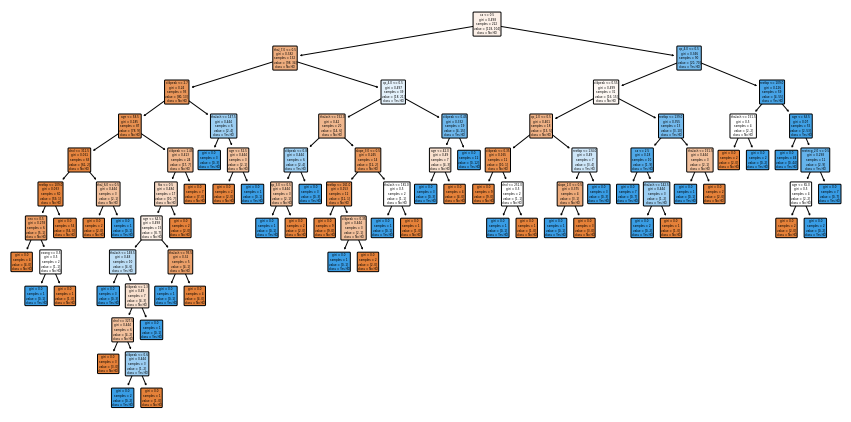

```python
plt.figure(figsize=(15, 7.5))

plot_tree(clf_dt,
         filled = True,
         rounded = True,# draw node boxes with rounded corners
         class_names = ['No HD', 'Yes HD'],
         feature_names = X_encoded.columns);
```

4. See how it performs on the Testing Dataseet by running the Testing Dataset down the tree and drawing a **Confusion Matrix**

```
<sklearn.metrics._plot.confusion_matrix.ConfusionMatrixDisplay at 0x7f3844644220>
```

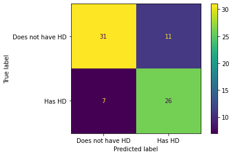

```python
## plot_confusion_matrix will run the test data down the tree and draw a cunfusion matrix
## see https://scikit-learn.org/stable/modules/generated/sklearn.metrics.plot_confusion_matrix.html
plot_confusion_matrix(clf_dt, X_test, y_test, display_labels=['Does not have HD', 'Has HD'])
```

We see that 31 + 11 = 42 people that did not have Heart Disease, 31 (74%) were correctly classified and that of the 7 + 26 = 33 people that have Heart Disease, 26 (79%) were correctly classified. Now let's attempt to do better. One thing that might be holding this classification tree back is that it may have overfit the training dataset. So let's prune the tree.

# Cost Complexity Pruning

## Part 1: Visualize alpha

Pruning a tree with **cost complexity pruning** can simplify the whole process of finding a smaller tree that improves the accuracy with the testing dataset.

Pruning a tree is all about finding the right value for the pruning parameter, alpha, which controls how much pruning happens. To find the optimal value for alpha, we **plot the accuracy of the tree as a function of different values of alpha**.

```python
path = clf_dt.cost_complexity_pruning_path(X_train, y_train) # determine the values for alpha and impurities
path
```

```
{'ccp_alphas': array([0.        , 0.00295295, 0.003861  , 0.00405405, 0.004095  ,
        0.00429358, 0.00514801, 0.00541298, 0.00578761, 0.00600601,
        0.00600601, 0.00600601, 0.00667591, 0.00675676, 0.00757375,
        0.00811505, 0.00868726, 0.00889851, 0.01038181, 0.0105777 ,
        0.01422475, 0.01604051, 0.01642461, 0.02103075, 0.03680006,
        0.03934523, 0.13046216]),
 'impurities': array([0.        , 0.00885886, 0.02430287, 0.03241098, 0.04060099,
        0.04918815, 0.06463216, 0.08628407, 0.10364689, 0.1156589 ,
        0.12767091, 0.13367692, 0.14035282, 0.14710958, 0.15468333,
        0.17091343, 0.17960069, 0.18849919, 0.19888101, 0.2094587 ,
        0.2379082 , 0.25394872, 0.27037333, 0.29140408, 0.32820413,
        0.36754937, 0.49801153])}
```

```python
ccp_alphas = path.ccp_alphas # select only the values for alpha
ccp_alphas = ccp_alphas[:-1] # exclude the maximum value for alpha
# this value would prune all leaves, leaving us only with a root instead of a tree

clf_dts = [] # array of decision trees

# time to create a decision tree for each value of alpha and store it in the array
for ccp_alpha in ccp_alphas:
    clf_dt = DecisionTreeClassifier(random_state = 0, ccp_alpha=ccp_alpha)
    clf_dt.fit(X_train, y_train)
    clf_dts.append(clf_dt)
```

```python
ccp_alphas
```

```
array([0.        , 0.00295295, 0.003861  , 0.00405405, 0.004095  ,
       0.00429358, 0.00514801, 0.00541298, 0.00578761, 0.00600601,
       0.00600601, 0.00600601, 0.00667591, 0.00675676, 0.00757375,
       0.00811505, 0.00868726, 0.00889851, 0.01038181, 0.0105777 ,
       0.01422475, 0.01604051, 0.01642461, 0.02103075, 0.03680006,
       0.03934523])
```

Now let's graph the accuracy of the trees using the Training Dataset and the Testing Dataset as a function of alpha

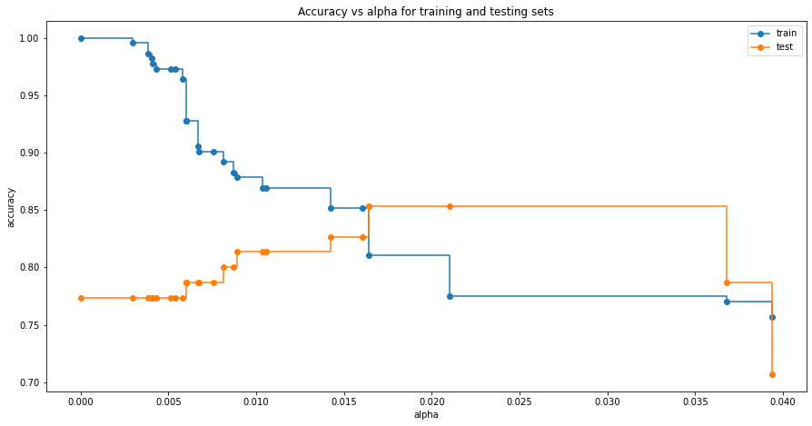

```python
train_scores = [clf_dt.score(X_train, y_train) for clf_dt in clf_dts] # score each tree for the training dataset
test_scores = [clf_dt.score(X_test, y_test) for clf_dt in clf_dts] # score each tree for the testing dataset

fig, ax = plt.subplots(figsize=(15, 7.5))
ax.set_xlabel('alpha')
ax.set_ylabel('accuracy')
ax.set_title('Accuracy vs alpha for training and testing sets')
ax.plot(ccp_alphas, train_scores, marker='o', label='train', drawstyle='steps-post')
ax.plot(ccp_alphas, test_scores, marker = 'o', label='test', drawstyle='steps-post')
ax.legend()
plt.show()
```

In the graph above, we see that the accuracy for the Testing Dataset hits its maximum value when alpha is about 0.016. After this value for alpha, the accuracy of the Training Dataset drops off and that suggests we should set ccp_alpha = 0.016

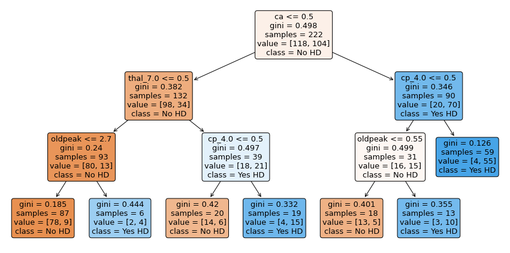

```python
plt.figure(figsize=(15, 7.5))

plot_tree(clf_dts[21], # classification tree for alpha = 0.016
         filled = True,
         rounded = True,# draw node boxes with rounded corners
         class_names = ['No HD', 'Yes HD'],
         feature_names = X_encoded.columns);
```

```
<sklearn.metrics._plot.confusion_matrix.ConfusionMatrixDisplay at 0x7f38038f7520>
```

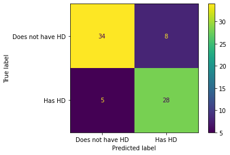

```python
## plot_confusion_matrix will run the test data down the tree and draw a cunfusion matrix
## see https://scikit-learn.org/stable/modules/generated/sklearn.metrics.plot_confusion_matrix.html
plot_confusion_matrix(clf_dts[21], X_test, y_test, display_labels=['Does not have HD', 'Has HD'])
```

## Part 2: Cross Validation for Finding the Best Alpha

Now, since there are many ways we could have divifed the original dataset into Training and Testing datasets, how do we know we used the best Training Dataset and how do we know we used the best Testing Dataset? We can answer this question using **10-Fold Cross Validation**, using the cross_val_score() function.

First, let's demonstrate that different training and testing datasets result in trees with different accuracies when we set ccp_alpha = 0.016. We will do this by using the cross_val_score() function to generate different training and testing datasets and then train and test the tree with those datasets.

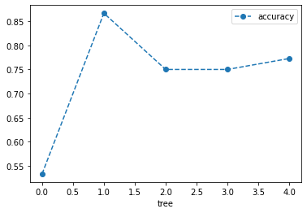

```python
clf_dt = DecisionTreeClassifier(random_state = 42, ccp_alpha = 0.016) # create the tree with the previous ccp_alpha

# now use 5-fold cross validation to create 5 different trainign and testing datasets that are then used to train
# and test the tree. We use 5-fold and not 10-fold since our dataset is not that big
scores = cross_val_score(clf_dt, X_train, y_train, cv = 5)
df = pd.DataFrame(data={'tree': range(5), 'accuracy': scores})

df.plot(x='tree', y='accuracy', marker='o', linestyle='--')
```

The graph above shows that using different training and testing data with the same alpha resulted in different accuracies, suggesting that alpha is sensitive to datasets. So, instead of picking a single training dataset and a single testing dataset, let's use cross-validation to find the optimal value for ccp_alpha.

See https://scikit-learn.org/stable/modules/generated/sklearn.model_selection.cross_val_score.html for cross validation documentation.

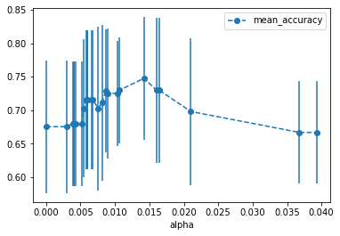

```python
alpha_loop_values = [] # array to store results of each fold during cross-validation

# for each candidate for alpha, we will run a 5-fold cross validation
# then we will store the mean and standard deviation of the scores (the accuracy) for each
# call to cross_val_score in alpha_loop_values
for ccp_alpha in ccp_alphas:
    clf_dt = DecisionTreeClassifier(random_state = 0, ccp_alpha = ccp_alpha) # create the tree object
    scores = cross_val_score(clf_dt, X_train, y_train, cv = 5)
    #print(scores)
    alpha_loop_values.append([ccp_alpha, np.mean(scores), np.std(scores)])

#print(alpha_loop_values)

# to draw a graph for the means and standard deviations of the scores
alpha_results = pd.DataFrame(alpha_loop_values,
                            columns=['alpha','mean_accuracy','std'])
alpha_results.plot(x='alpha',y='mean_accuracy',yerr='std',
                    marker = 'o',
                    linestyle='--')
```

We can see that instead of setting ccp_alpha = 0.016, we need to set it to something closer to 0.014, overall. To find the exact value:

```python
alpha_results[(alpha_results['alpha'] > 0.014) & (alpha_results['alpha'] < 0.015)]
```

|  | alpha | mean_accuracy | std |
| --- | --- | --- | --- |
| 20 | 0.014225 | 0.747778 | 0.091395 |

Store the ideal value for alpha so we can use it to build the tree

```python
ideal_ccp_alpha = alpha_results[(alpha_results['alpha'] > 0.014)
                                & (alpha_results['alpha'] < 0.015)]
ideal_ccp_alpha # this is a series
```

|  | alpha | mean_accuracy | std |
| --- | --- | --- | --- |
| 20 | 0.014225 | 0.747778 | 0.091395 |

```python
ideal_ccp_alpha = float(ideal_ccp_alpha.alpha) # obtain solely the value for alpha
ideal_ccp_alpha
```

```
0.014224751066856332
```

# Building, Evaluation, Drawing, and Interpretin the Final Classification Tree

Now that we have the ideal value for alpha, we can build, evaluate and draw the final Classification Tree.

```python
clf_dt_pruned = DecisionTreeClassifier(random_state = 42, ccp_alpha = ideal_ccp_alpha) # set the tree with optimal alpha

clf_dt_pruned = clf_dt_pruned.fit(X_train, y_train)
```

Plot confusion matrix to see if the pruned tree does better

```
<sklearn.metrics._plot.confusion_matrix.ConfusionMatrixDisplay at 0x7f3800e6f2b0>
```

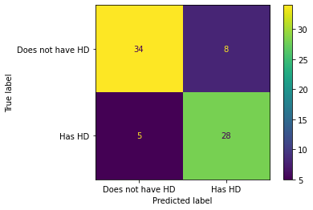

```python
plot_confusion_matrix(clf_dt_pruned,
                     X_test,
                     y_test,
                     display_labels=['Does not have HD', 'Has HD'])
```

We see that the pruned tree is better at classifying patients than the full sized tree.

**Finally, draw the tree.**

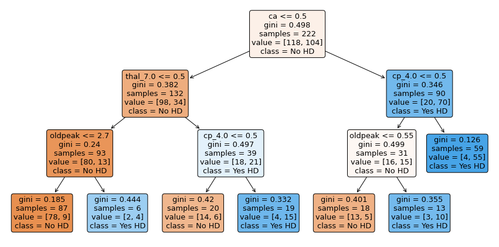

```python
plt.figure(figsize=(15, 7.5))

plot_tree(clf_dt_pruned, # classification tree for alpha = 0.016
         filled = True,
         rounded = True,# draw node boxes with rounded corners
         class_names = ['No HD', 'Yes HD'],
         feature_names = X_encoded.columns);
```

**How to interpret the tree. In each node we have:**

1. The variable (column name) and the threshold for splitting the observations.
2. gini is the gini index or score of that node
3. samples tells us how many samples are in that node
4. value tells us how many samples in the node are in each category
5. class tells us whichever category is represented most in the node